# Borrowers Characteristics That Influence the Prosper Loan Amount

## by (Ludmila Mucavele)

## Investigation Overview

For the presentation, I focus on loan original amount count and status, so as the influence of the borrowers in relation to its characteristics.

## Dataset Overview

This document explores the Prosper Loan dataset that contains 113,937 loans with 81 variables on each loan, including loan amount, borrower rate (or interest rate), current loan status, borrower income, and many others. The last update of the dataset was in 03/11/2014.

## Distribution of Loan Original Amount

The Loan amount is distributed from 1000 (\$) to 35000 (\\$). When plotted on a logharitmic scale, the amount distribution looks multimodal with many peaks. Some of them are between 3500 and 6000 (\$), 6000 and 12000 (\\$), 12000 and 17500 (\$), and so on; other peaks are below 4000 (\\$).

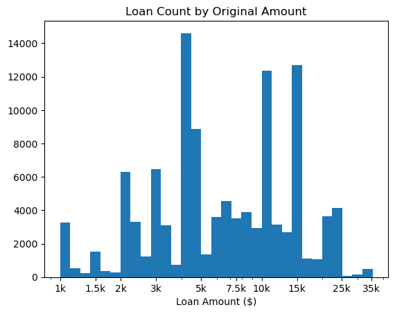

## Distribution of Loan Status

Most of the loans were currently being paid in that season, but many of them were completed too. There is a good amount of loans which payment has not been made by its cutoff time (Past Due), and very few loans are in their final payment progress, but only 5 are cancelled.

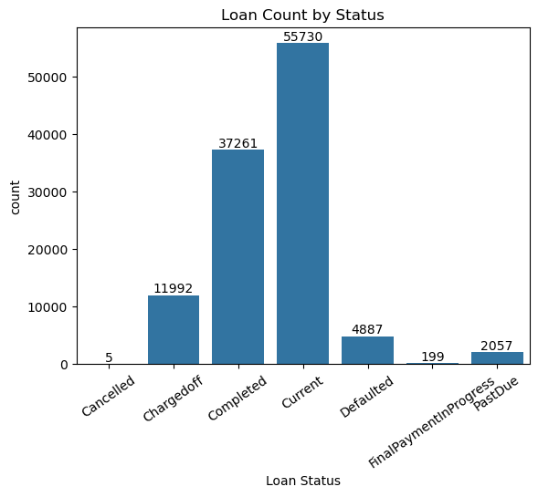

## Loan Original Amount vs. Monthly Loan Payment

The Loan Original Amount is highly related to Monthly Loan Payment positively, where most of the distribution is concentrated betweet 0 and 25,000 (\$) loan original amount. This could mean that the higher the Loan Original Amount, the higher the Monthly Loan Payment gets.

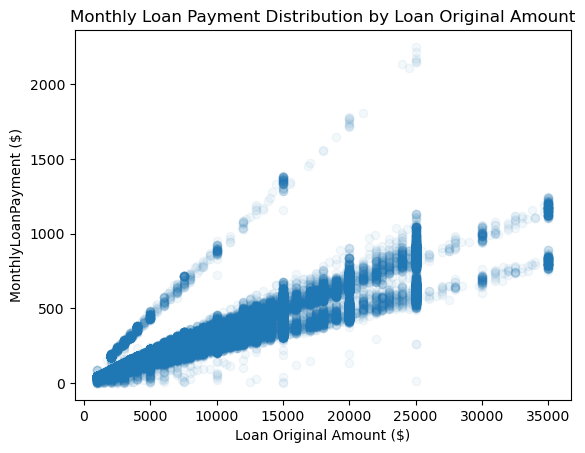

## Loan Original Amount / Stated Monthly Income vs. Employment Status

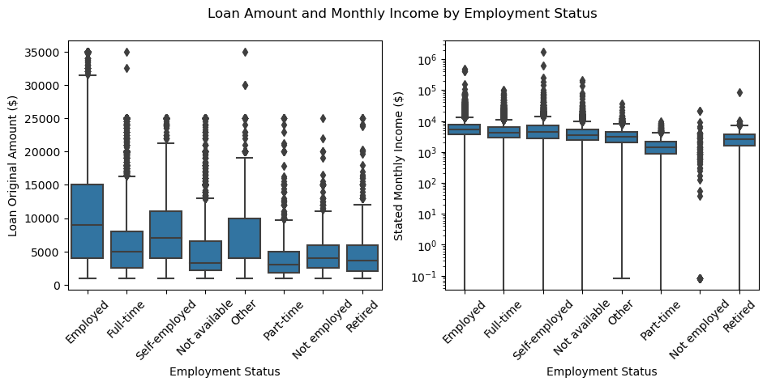

## Prosper Payment One Month Later or More by Loan AMount and Employment Status

Besides the Employed borrower being in majority, no matter the loan original amount or the employment status of the borrower, the borrower still can make payments one month later or more. We can see that most of the borrowers do not fail in paying the loan on time too.

[figure not shown]